# **Isabela Pereira Lima Dias** - [Github](https://github.com/isadays)

## Task 1: Visual Data analysis

Pick some data of your choice and generate some visualization of it in a tool of your choice. Briefly explain the data and the visualization decision.

In this exercise, we deal with Visualization Toolkit (VTK) functions. The choice of such a task is due to the goal-oriented purpose, in which we provide a visual data analysis of a structured dataset(hydrogen atom). The objective is to test Python scripting with VTK.

Why animations? The main objective is to track objects and estimating changes, as we can see, the shape of the orbitals (isocontours) changes with the density probability values.

**Isosurface extraction**: In this script, we extract and display iso-contours of the probability density of the hydrogen atom orbital 3d. The isocontours are color-mapped according to the probability density values.

- Python script: hydrogen.py
- The dataset: hydrogen.vtk

**Resources**:

vtk.vtkStructuredPointsReader(): reads ".vtk" legacy format files containing image data.

vtk.vtkOutlineFilter(): create a wireframe outline around the input dataset

vtk.vtkPolyDataMapper(): maps polygonal data to the graphics system.

vtk.vtkActor(): groups rendering attributes such as surface properties

vtk.vtkContourFilter(): generates the isosurfaces

vtk.vtkColorTransferFunction(): mapping of scalar value to color using either an RGB or HSV color space

vtk.vtkScalarBarActor(): a labeled, colored bar that visually expresses the relationship between color and scalar value

vtk.vtkRenderer() : The objects that make up a scene including the props, the camera and the lights are collected together in a vtkRenderer

vtk.vtkRenderWindowInteractor() : is responsible for processing mouse, key, and timer events and routing these through VTK's implementation of the command.

vtk.vtkScalarBarWidget() : Manage a vtkScalarBar including positioning, scaling, and orienting it

vtk.vtkAnimationScene() : represents a scene or a setup for the animation

**References**:

- The exercise is from Scientific Visualization Course at Uppsala University. [Available here](https://www.it.uu.se/edu/course/homepage/vetvis/ht09/ComputerExercises/assignment1.shtml).
- The VTK User's Guide [Available here](https://vtk.org/wp-content/uploads/2021/08/VTKUsersGuide.pdf).
- Xiaoying Pu, Sean Kross, Jake Hofman, Daniel Goldstein. In Proceedings of the 2021 CHI Conference on Human Factors in Computing Systems, pp. 1-14.(CHI 2021) [Available here](http://www.jakehofman.com/pdfs/datamations.pdf).

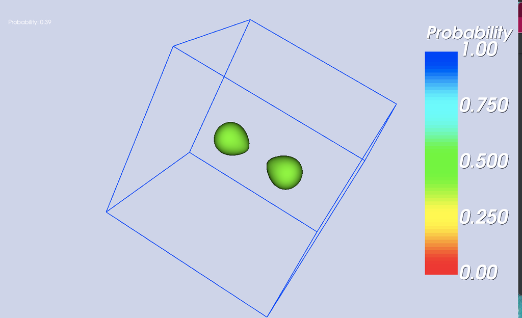

In this animation, it is possible to reinitiate the animation by double clicking on the screen.

## Task 2: Topological concepts for data analysis

**Question 1**. A frequent visualization method for 2-dimensional scalar fields,$S : \mathbb{R}^{2}→ \mathbb{R}$, is *isocontours* (also called isolines). How are such lines mathematically defined?

*Solution*: The isocontours are sets of points in a dataset $\mathcal{D}$ to a given scalar value $u \in \mathbb{R}$,

$$\{ x,y,z \in D| S(x,y,z) = u\} = s^{-1}(u), \ with \ \mathcal{D}\subset \mathbb{R}^{3} $$

, where $s^{-1}(u)$ is a level set.

For $3D$ datasets, contours are $2D$ surfaces called isosurfaces. We show, in the next exercise, an example of $2D$ scalar field with contour lines, $S: \mathcal{D} → \mathbb{R}, \ with \ \mathcal{D}\subset \mathbb{R}^{2}.$ For instance, consider the plot of a $2D$ scalar field.

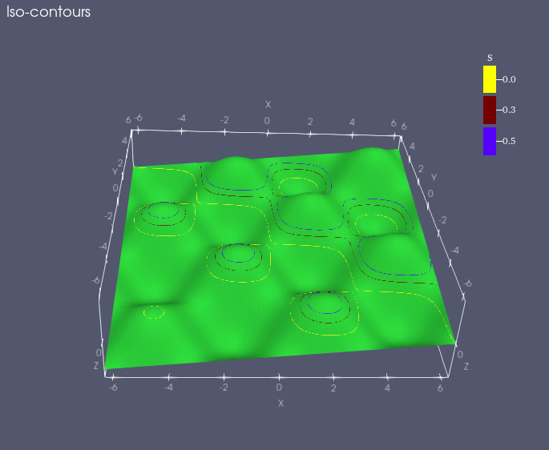

Three isolines are drawn over the graph, for three different values. The isolines are translated on the $z$ axis above the $xy$ plane with their corresponding values $u$.

**Question 2** A concept from topological data analysis that builds on the notion of iso-contours is the contour tree. Try to find out what a contour tree is and explain the concept briefly.

*Solution*: The topological data analysis looks at topological changes in the isocontours. The topology of the critical points of a function reveals interesting features to construct contour graphs, contour trees, or Hyper Reeb Graph, allowing the exploration of the dataset. The contour tree tracks the connectivity of the level sets of a given function, i.e., the changes in the number of components of the contours according to scalar values.

Given a scalar function $f: \mathcal{D} → \mathbb{R}$, two points $x,y \in \mathcal{D}$ are related, $x~y$, if they belong to the same component of the level set $f^{-1}(f(x)) = f^{-1}(f(y))$. A Reeb graph is constructed by continuously contracting the level set components of $f$ to points, considering how they merge and split. The contour tree is a graph (V, E) composed of V nodes and E arcs. Each critical value is a node, and a contour class corresponds to an arc.

For instance, consider the 2D scalar field given in Task 3, which provides an intuitive visualization of the segmentation of a contour tree. The graph shows the connections between the type (Maxima, minima, or saddle points) of the critical points and the isocontours.

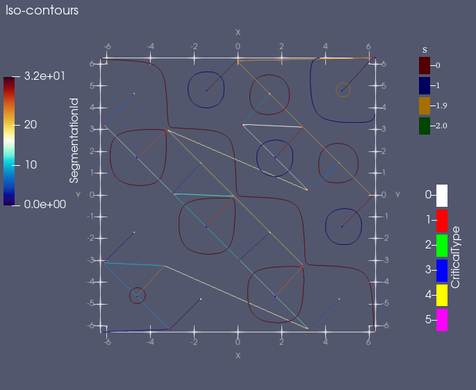

The segmentation is then related with the topology connectivity describing the graph structure.

**References**:

1. Topological Methods in Data Analysis and Visualization III. (Springer International Publishing, 2014). doi:10.1007/978-3-319-04099-8.
2. Tierny, J. Topological Data Analysis for Scientific Visualization. (Springer International Publishing, 2017). doi:10.1007/978-3-319-71507-0.
3. Telea, A. Data Visualization. (A K Peters/CRC Press, 2014). doi:10.1201/b17217.

## Task 3:Programming task

In the attached file “2d_scalar_field.csv” you are given a 2D scalar function sampled on a $100 × 100$ grid. In each row, information about the coordinates $(𝑥, 𝑦)$ of the sample point along with the function value $(𝑆)$ at the point are provided.

Write a program in a programming language of your choice to:

- compute iso-contours for the given data set. You can take the csv file and the isovalue as the command line arguments. Try extracting iso-contours for the following three isovalues {0, 1, 2}.
- find the minima, maxima, and saddle points in the data set. Take a look at the following illustration for visual explanation of these special points in 2D scalar field.

Solution:

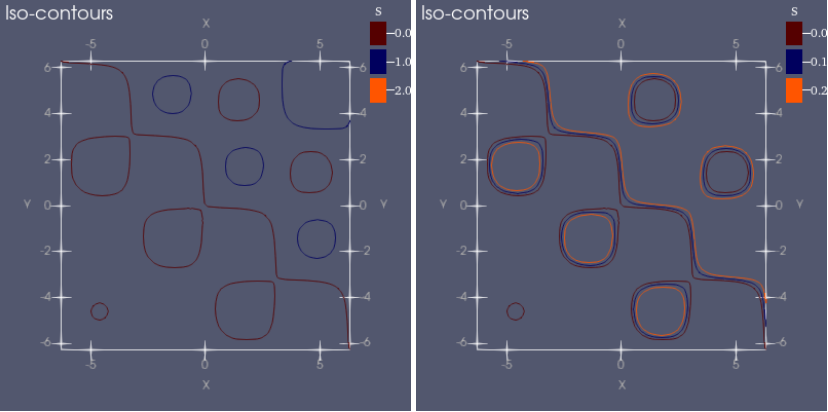

The Table shows the critical points of the dataset, as well their classification.

```python
import pandas as pd
df = pd.read_csv('scalarfieldcroutputClass.csv')
df[['S','x','y','Classification']]
```

|  | S | x | y | Classification |
| --- | --- | --- | --- | --- |
| 0 | -1.256600 | -6.283000 | -6.283000 | Local Minimum |
| 1 | -0.930620 | -3.109800 | -6.156100 | Saddle Type 1 |
| 2 | -0.303980 | 3.236700 | -6.156100 | Saddle Type 1 |
| 3 | -1.636100 | -1.713500 | -4.759800 | Local Minimum |
| 4 | -1.008400 | 4.632900 | -4.759800 | Local Minimum |
| 5 | 0.067114 | -4.632900 | -4.632900 | Local Maximum |
| 6 | 0.694770 | 1.713500 | -4.632900 | Local Maximum |
| 7 | -0.639120 | -3.363600 | -3.236700 | Saddle Type 1 |
| 8 | -0.010374 | 2.982800 | -3.236700 | Saddle Type 1 |
| 9 | -0.930620 | -6.156100 | -3.109800 | Saddle Type 1 |
| 10 | -0.301960 | 0.063465 | -2.982800 | Saddle Type 1 |
| 11 | -1.636100 | -4.759800 | -1.713500 | Local Minimum |
| 12 | -1.009100 | 1.459700 | -1.713500 | Local Minimum |
| 13 | 0.695770 | -1.459700 | -1.459700 | Local Maximum |
| 14 | 1.322700 | 4.759800 | -1.459700 | Local Maximum |
| 15 | -0.013384 | -0.190390 | -0.063465 | Saddle Type 1 |
| 16 | 0.617300 | 6.156100 | -0.063465 | Saddle Type 1 |
| 17 | -0.301960 | -2.982800 | 0.063465 | Saddle Type 1 |
| 18 | 0.324740 | 3.236700 | 0.190390 | Saddle Type 1 |
| 19 | -1.009100 | -1.713500 | 1.459700 | Local Minimum |
| 20 | -0.381440 | 4.632900 | 1.459700 | Local Minimum |
| 21 | 0.694770 | -4.632900 | 1.713500 | Local Maximum |
| 22 | 1.322500 | 1.713500 | 1.713500 | Local Maximum |
| 23 | -0.010374 | -3.236700 | 2.982800 | Saddle Type 1 |
| 24 | 0.614290 | 2.982800 | 3.109800 | Saddle Type 1 |
| 25 | -0.303980 | -6.156100 | 3.236700 | Saddle Type 1 |
| 26 | 0.324740 | 0.190390 | 3.236700 | Saddle Type 1 |
| 27 | -1.008400 | -4.759800 | 4.632900 | Local Minimum |
| 28 | -0.381440 | 1.459700 | 4.632900 | Local Minimum |
| 29 | 1.322700 | -1.459700 | 4.759800 | Local Maximum |
| 30 | 1.949700 | 4.759800 | 4.759800 | Local Maximum |
| 31 | 0.617300 | -0.063465 | 6.156100 | Saddle Type 1 |
| 32 | 1.243900 | 6.156100 | 6.283000 | Saddle Type 1 |
| 33 | 1.256600 | 6.283000 | 6.283000 | Local Maximum |

We found the following critical points

```python
# Print counts of maxima, minima, and saddle points
maxima_count = df[df['Classification'] == 'Local Maximum'].shape[0]
minima_count = df[df['Classification'] == 'Local Minimum'].shape[0]
saddle_count = df[(df['Classification'] == 'Saddle Type 1') | (df['Classification'] == 'Saddle Type 2')].shape[0]

print(f"Number of Local Maxima: {maxima_count}")
print(f"Number of Local Minima: {minima_count}")
print(f"Number of Saddle Points: {saddle_count}")
```

```
Number of Local Maxima: 9
Number of Local Minima: 9
Number of Saddle Points: 16
```

**Resources**:

1. In the provided code, the CSV table is converted to a dataset using the "TableToPoints" filter. In this step, we transform the row tabular data (CSV table) into a structured Data Format: The "TableToPoints" filter is used to convert the CSV table into a point cloud dataset. Each row in the CSV table corresponds to a point in the resulting dataset.

Next, we will explore the topology, i.e, the connections among points.

1. Data Interpolation - Delaunay2D: After the conversion to a point cloud dataset, the script applies the Delaunay2D filter to interpolate and triangulate the points, creating a surface that represents the spatial distribution of the scalar field ('S'). 'The input to this filter is a list of points specified in 3D, even though the triangulation is 2D. Thus the triangulation is constructed in the x-y plane, and the z ('S') coordinate is ignored. '
2. Contour Filter: Generates isocontours based on the scalar field values. The Contour filter is used to create curves (iso-contours) on the surface generated by the Delaunay triangulation. Each isocontour represents points on the surface where the scalar field has a specific value. Then we can choose specific values of the scalar field to use for contouring. In this case, it is set to ['POINTS', 'S'], indicating that the isocontours are based on the scalar field ('S') associated with the points.

**TOPOLOGYCAL ANALYSIS**

1. The TTK ScalarFieldCriticalPoints Filter computes the list of critical points of the input scalar field and classify them according to their type. TTK ScalarFieldCriticalPoints (tTKScalarFieldCriticalPoints1):Purpose: Extracts critical points (minima, maxima, and saddles) from the scalar field.